# edX Gun Murders

Irene Shea

3/16/2021

## Introduction

When we started talking about Gun Murders in edX I had a very “oh no” moment. Texas, the state of my heart, has a reputation of being full of gun-slinging cowboys. Maybe it’s just been the current atmosphere of things, but when we started working with this dataset, I was afraid this report would devolve into another state-bashing session. It might be a stereotype that Texans love their state the best, but it’s a true one, and I wasn’t excited for some Massachusetts Yankee to come in and wag their finger at us, Harvard professor or not. As it turns out, Texas did not rank the highest on gun murders across the 50 states, but the South does have a higher rate of death by gun than any other region of the country. So, maybe the stereotype isn’t entirely unfounded.

Disclaimer: This is a practice report. It does not seek to investigate why the murder rates differ between states. In addition, the findings below are based on data from 2010 on US Gun Murder Rates found on Wikipedia (https://en.wikipedia.org/wiki/Murder_in_the_United_States_by_state) and are not indicative of what gun murder rates are today, more than a decade later.

## Focus Question

Does Texas actually live up to its reputation as a dangerous gun-toting cowboy state?

I used the following libraries and pre-wrangled data:

```r
library(dslabs)
library(tidyverse)
data(murders)
```

## Barplot of State Population and Gun Murders

At first I wanted to compare state sizes with gun deaths, but I quickly realized this data table does not include land mass when factoring in the number of deaths so it’s probably related to population size. Occam’s Razor would state that states with the largest populations probably have the most gun deaths, and the smallest states probably have the least. So I tested that with the code below.

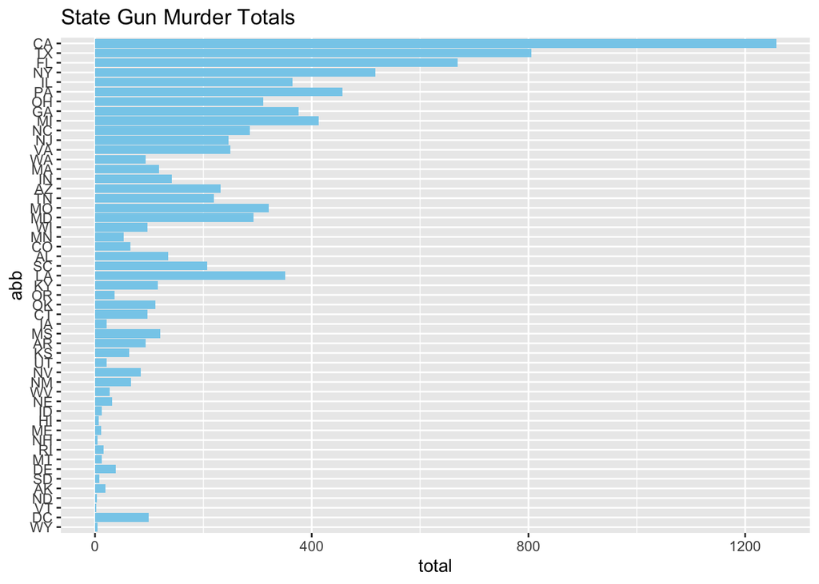

Here, state abbreviations are ordered by population size with the bar length indicating total number of deaths. California has the largest population and the most gun deaths. Though Wyoming doesn’t have the lowest gun deaths, it does have the smallest population. I confirm my observations below.

```r
murders$state[which.max(murders$population)]
```

```
## [1] "California"
```

```r
which.max(murders$population) == which.max(murders$total)
```

```
## [1] TRUE
```

California has the largest population and the most gun deaths by total.

```r
murders$state[which.min(murders$population)]
```

```
## [1] "Wyoming"
```

```r
which.min(murders$population) == which.min(murders$total)
```

```
## [1] FALSE
```

Wyoming has the smallest population, but it does not have the least gun deaths by total. It’s not just population size that contributes to gun deaths. There must be something else at work.

## Barplot of State Rates of Gun Murder

Because states all have different population sizes, it would be more fair to compare murder rates rather than murder totals. With all the states on equal footing, I determined which states were above average in terms of gun deaths.

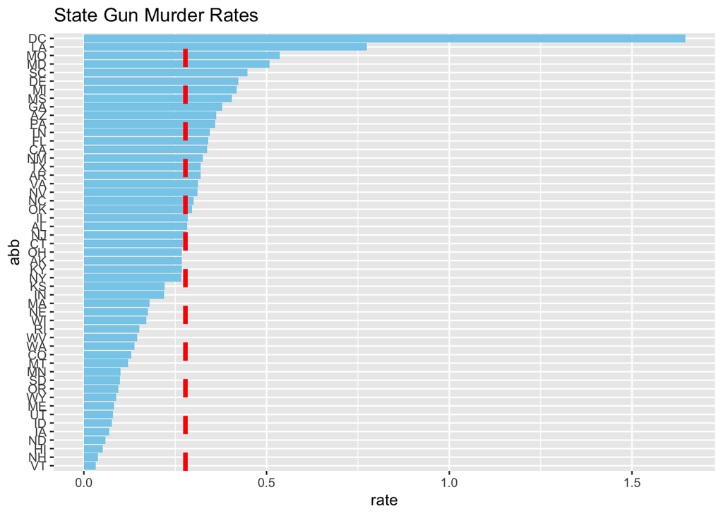

Based on the graph, we can see the District of Columbia has highest and Vermont has the lowest rate of gun deaths. It also looks like approximately half of the states have rates of gun murder above the national average. The 24 states that have above average rates of gun murders are shown below in order from highest to lowest.

```
##    rank                state
## 1     1 District of Columbia
## 2     2            Louisiana
## 3     3             Missouri
## 4     4             Maryland
## 5     5       South Carolina
## 6     6             Delaware
## 7     7             Michigan
## 8     8          Mississippi
## 9     9              Georgia
## 10   10              Arizona
## 11   11         Pennsylvania
## 12   12            Tennessee
## 13   13              Florida
## 14   14           California
## 15   15           New Mexico
## 16   16                Texas
## 17   17             Arkansas
## 18   18             Virginia
## 19   19               Nevada
## 20   20       North Carolina
## 21   21             Oklahoma
## 22   22             Illinois
## 23   23              Alabama
## 24   24           New Jersey
```

## Boxplot of Regional Gun Murder Rates

I was surprised Louisiana, Texas’s neighboring state ranked as high as it did, so I wanted to see if maybe there were trends across regions. Were there some regions with higher gun murder rates than others?

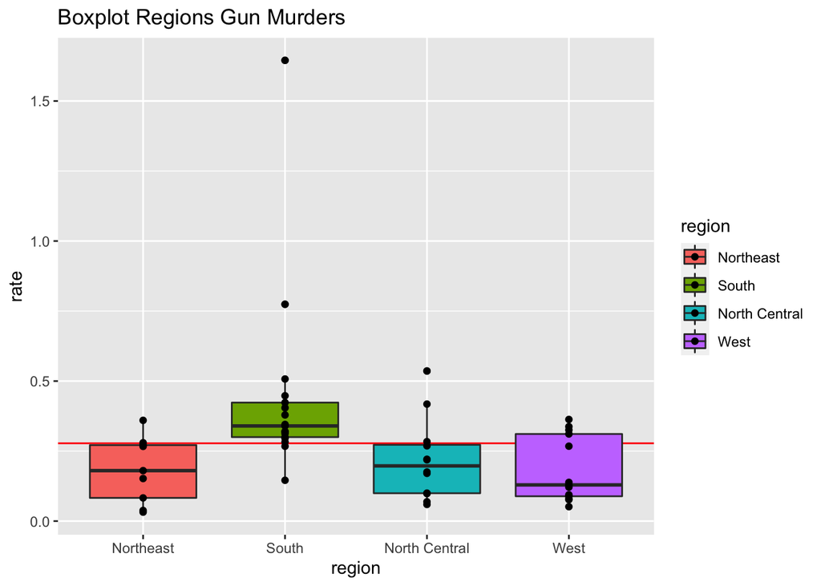

Compared to the other regions, the South has the highest rates of gun murder; the entirety of its IQR sits above the national average. However, the outlier surprised me. Which state was that? Wasn’t the state with the highest murder rate DC?

```
##                  state abb region population total     rate
## 1 District of Columbia  DC  South     601723    99 1.645275
```

TIL: The District of Columbia is in the south. Well, you say, DC is technically not a state. So, what if we don’t include it?

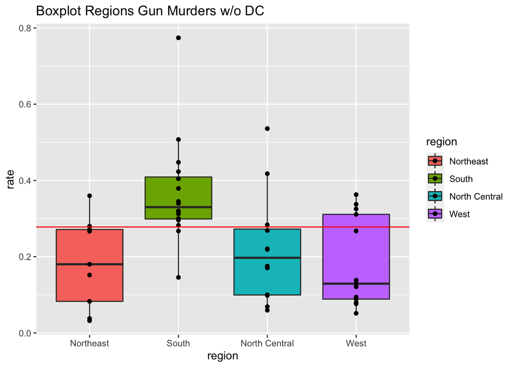

If we throw out the outlier the boxplots don’t change by much. In fact, we can see even more clearly that the South has higher rates of gun murder than any other region in the United States.

## Conclusions

So, does Texas live up to its dangerous reputation with guns? Though larger states like Texas do record more gun deaths, they don’t necessarily have higher rates of gun murders when the size of the population is taken into account. About half of the states in the country (including Texas) have higher-than-average gun murders. And when organizing states by region, we can see that the South has the highest rate of gun murder.

I am relieved that the rate of gun deaths aren’t the worst in Texas, but it’s still higher than it would be in any other region of the country, so it isn’t much to brag about.

Ultimately, I’ve discovered that the real cowboy state is Washington DC, which has the highest rates of gun murders by far. You know, I’ve always associated cowboys with a special kind of lawlessness, but DC is where laws literally get made. Is that? The joke? Is this why we were assigned this dataset Mr. Professor Man?

## Further Research

Why does DC have the highest gun murder rates? And, as I mentioned earlier in the report, this data is from more than a decade ago. How have patterns changed in the years since? Have laws changed in states since?

This report doesn’t take into account migration patterns, urban density, socioeconomic status, who is getting killed, who is doing the killing, current events, and laws and legislature, things which all vary considerably from state to state and year to year. Something to look into in the future.